# SENDAs Agreement 1 Update 2010-2022

2.2.2.a, Entries: 54

2.2.2.a, RUNs: 18

2.2.2.b. Used PO date if within percentiles 1 and 99

2.2.2.b, Entries: 256

2.2.2.b, RUNs: 133

2.2.2.c. Multiple birth dates; chose most frequent; ties -> closest to average

2.2.2.c, Entries: 2

2.2.2.c, RUNs: 1

2.2.2.d. No valid birthdate; selected closest to average

2.2.2.d, Entries: 0

2.2.2.d, RUNs: 0

2.2.2.e. Single birth date available; selected

2.2.2.e, Entries: 28

2.2.2.e, RUNs: 15

2.2.2.f. Single date outside valid range; selected as is

2.2.2.f, Entries: 4

2.2.2.f, RUNs: 2

2.2.2.g. Get birth year from hospital avg; keep month/day from other sources

2.2.2.g, Entries: 8

2.2.2.g, RUNs: 3

2.2.2.h. Selected date closest to average birth date

2.2.2.h, Entries: 0

2.2.2.h, RUNs: 0

2.2.2.i. Unresolvable inconsistencies or extremely implausible birth dates

2.2.2.i, Entries: 2

2.2.2.i, RUNs: 2

```r
# 2.2.2.a, Entries: 54 #54
# NULL
# 2.2.2.a, RUNs: 18 #18
# NULL
# 2.2.2.b, Entries: 36 #232
# NULL
# 2.2.2.b, RUNs: 18 #122
# NULL
# 2.2.2.c, Entries: 11 #2
# NULL
# 2.2.2.c, RUNs: 5 #1
# NULL
# 2.2.2.d, Entries: 18 #14
# NULL
# 2.2.2.d, RUNs: 8 #6
# NULL
# 2.2.2.e, Entries: 183 #35
# NULL
# 2.2.2.e, RUNs: 92 #18
# NULL
# 2.2.2.f, Entries: 7 #7
# NULL
# 2.2.2.f, RUNs: 4 #4
# NULL
# 2.2.2.g, Entries: 31 #11
# NULL
# 2.2.2.g, RUNs: 13 #4
# NULL
# 2.2.2.h, Entries: 0 #0
# NULL
# 2.2.2.h, RUNs: 0 #0
# NULL
# 2.2.2.i, Entries: 19 #4
# NULL
# 2.2.2.i, RUNs: 19 #4

#AUG 2025,
# 2.2.2.a. Prioritized birthdate of mortality database
# 2.2.2.a, Entries: 54
# 2.2.2.a, RUNs: 18
# 2.2.2.b. Used PO date if within percentiles 1 and 99
# 2.2.2.b, Entries: 256
# 2.2.2.b, RUNs: 133
# 2.2.2.c. Multiple birth dates; chose most frequent; ties -> closest to average
# 2.2.2.c, Entries: 2
# 2.2.2.c, RUNs: 1
# 2.2.2.d. No valid birthdate; selected closest to average
# 2.2.2.d, Entries: 0
# 2.2.2.d, RUNs: 0
# 2.2.2.e. Single birth date available; selected
# 2.2.2.e, Entries: 28
# 2.2.2.e, RUNs: 15
# 2.2.2.f. Single date outside valid range; selected as is
# 2.2.2.f, Entries: 4
# 2.2.2.f, RUNs: 2
# 2.2.2.g. Get birth year from hospital avg; keep month/day from other sources
# 2.2.2.g, Entries: 8
# 2.2.2.g, RUNs: 3
# 2.2.2.h. Selected date closest to average birth date
# 2.2.2.h, Entries: 0
# 2.2.2.h, RUNs: 0
# 2.2.2.i. Unresolvable inconsistencies or extremely implausible birth dates
# 2.2.2.i, Entries: 2
# 2.2.2.i, RUNs: 2

#b002ce96b750e7e32aa9d2bdb611520e938293b7221415784fdb2fceeac52a8f, opciones raras, o 1917 o 2002
#a534782e4a670be9fe584f9b1b47a7f38a73f6b08f18aa7a7b4a45a7ba628dbf
#a3f5934a1b72932a34d89c71aec939a327499373107718abb42f437b5bc94254 por qué sólo una
#proc_invalid_adm_ages_long_w_po_and_c1_info |> filter(hash_key=="b002ce96b750e7e32aa9d2bdb611520e938293b7221415784fdb2fceeac52a8f") |> glimpse()
#_#_#_#_#_#_#_#_#_#_#_#_#_#_#_#_#_#_#_#_#_#_#_#_#_#_#_#_#_#_#_#_#_#_#_#_#_#_#_#_#_#_#_#_#_#_#_#_#_#_
```

[output not shown]

We added the corrected birth date and admission age.

```r
invisible("Check any errors in conversion of invalid ages: no ext data")
message(dplyr::inner_join(proc_birthdates_ext_data,proc_invalid_adm_ages_no_ext_data_long_w_po_and_c1_info, "hash_key") |> nrow())
```

0

```r
invisible("Check any errors in conversion of invalid ages: w/ ext data")
hashs_inconsistent_and_invalid_ages<-
proc_birthdates_ext_data |>
  dplyr::inner_join(proc_invalid_adm_ages_long_w_po_and_c1_info, "hash_key", multiple="first")

#e3d18a65489e87325c1a4e59286283a211b7ef31505bc48a4f62956cc491f5d3 dice que fue el único caso (2.2.2.e. Single birth date available, selected)

invisible("a534782e4a670be9fe584f9b1b47a7f38a73f6b08f18aa7a7b4a45a7ba628dbf")
#a534782e4a670be9fe584f9b1b47a7f38a73f6b08f18aa7a7b4a45a7ba628dbf only dates below 16
#already noticed in earlier stages

SISTRAT23_c1_2010_2024_df_prev1e<-
SISTRAT23_c1_2010_2024_df_prev1d|>
  tidylog::left_join(proc_invalid_adm_ages_no_ext_data_long_w_po_and_c1_info[,c("hash_key","sel_birth_date","FLAG")], by="hash_key", multiple="first")|>
  tidytable::rename("obs_invalid_dates_noext"="FLAG")|>
  tidylog::left_join(proc_invalid_adm_ages_long_w_po_and_c1_info[,c("hash_key","sel_birth_date","obs")], by="hash_key", multiple="first")|>
  tidytable::rename("obs_invalid_dates_ext"="obs")|>
  tidytable::mutate(birth_date_rec = tidytable::case_when( !is.na(obs_invalid_dates_noext)~ as.Date(sel_birth_date.x), T~birth_date))|>
  tidytable::mutate(birth_date_rec = tidytable::case_when( !is.na(obs_invalid_dates_ext)~ as.Date(sel_birth_date.y), T~birth_date_rec))|>
  tidytable::mutate(adm_age_rec= lubridate::time_length(lubridate::interval(birth_date_rec,adm_date_rec), "years"))|>
  tidytable::mutate(OBS = tidytable::case_when( !is.na(obs_invalid_dates_noext)~ glue("{OBS};{obs_invalid_dates_noext}"),T~OBS))|>
  tidytable::mutate(OBS = tidytable::case_when( !is.na(obs_invalid_dates_ext)~ glue("{OBS};{obs_invalid_dates_ext}"),T~OBS))|>
  tidytable::mutate(OBS= gsub("^;", "", OBS))|>
  tidytable::select(-any_of(c("sel_birth_date.x","obs_invalid_dates_noext","sel_birth_date.y","obs_invalid_dates_ext")))|>
  tidytable::as_tidytable()
```

left_join: added 2 columns (sel_birth_date, FLAG)

```
       > rows only in SISTRAT23_c1_2010_2024_..  174,040
       > rows only in proc_invalid_adm_ages_n.. (      0)
       > matched rows                                 85
       >                                        =========
       > rows total                              174,125
```

left_join: added 3 columns (sel_birth_date.x, sel_birth_date.y, obs) > rows only in tidytable::rename(tidyl.. 173,947 > rows only in proc_invalid_adm_ages_l.. ( 0) > matched rows 178 > ========= > rows total 174,125

```r
message(paste0("Number of entries w/ infrequent admission ages (>90|<16) or missing data= ",
    tidytable::filter(SISTRAT23_c1_2010_2024_df_prev1e, adm_age_rec>90|adm_age_rec<16|is.na(adm_age_rec))|> nrow(),"\n(HASHs= ",
    tidytable::filter(SISTRAT23_c1_2010_2024_df_prev1e, adm_age_rec>90|adm_age_rec<16|is.na(adm_age_rec))|> distinct(hash_key) |> nrow(),")"))
```

Number of entries w/ infrequent admission ages (>90|<16) or missing data= 48 (HASHs= 48)

```r
# Number of entries w/ infrequent admission ages (>90|<16) or missing data= 48
# (HASHs= 48)
message(paste0("Number of entries w/ missing data only= ",
    tidytable::filter(SISTRAT23_c1_2010_2024_df_prev1e, is.na(adm_age_rec))|> nrow(),"\n(HASHs= ",
    tidytable::filter(SISTRAT23_c1_2010_2024_df_prev1e, is.na(adm_age_rec))|> distinct(hash_key) |> nrow(),")"))
```

Number of entries w/ missing data only= 13 (HASHs= 13)

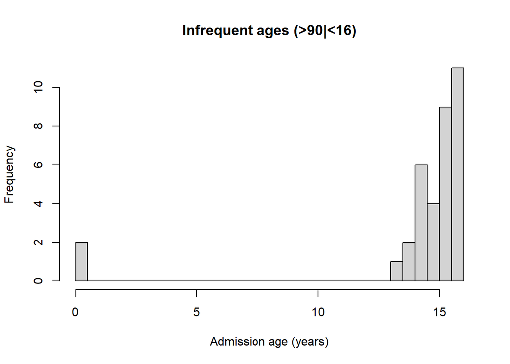

```r
#6d5f2fc8d4c835e227ac7f99c96f710c235b0415d95571a976b481f9170a4c34 has a missing date

# Number of entries w/ missing data only= 13
# (HASHs= 13)


tidytable::filter(SISTRAT23_c1_2010_2024_df_prev1e, adm_age_rec>90|adm_age_rec<16)|>
    pull(adm_age_rec)|>
    hist(breaks=50, main= "Infrequent ages (>90|<16)", xlab= "Admission age (years)")
```

For example, the ID `a534782e4a670be9fe584f9b1b47a7f38a73f6b08f18aa7a7b4a45a7ba628dbf` was associated only with age entries below 16 years old, also corroborated by external information.

Imputation methods were evaluated in the script `hist_scripts/Duplicates_24_imp_methods.R`. However, the imputation was not sufficiently precise —specifically, the imputed admission ages spanned nearly 10 years— so we chose not to use it. We discarded IDs with ages <13 and with missing ages.

```r
#hashs_invalid_adm_age

# We explored 3 types of imputation: using k-nearest neighbours, random forests and multiple imputation with chained equations. The variables used as candidates were: `"sexo"`, `"tipo_centro"`, `"tipo_de_plan"`, `"pais_nacimiento"`, `"se_trata_de_una_mujer_embarazada"`, `"escolaridad_ultimo_ano_cursado"`, `"sustancia_principal"`, `"edad_inicio_sustancia_principal"`, `"tiene_menores_de_edad_a_cargo"`, `"edad_inicio_consumo"`, `"numero_de_hijos"`, `"estado_conyugal"`, `"TABLE_rec2"`, `"numero_de_tratamientos_anteriores"`, `"usuario_de_tribunales_tratamiento_drogas"`.
#
# The following variables have specific characteristics that should be considered:
#
# - `tiene_menores_de_edad_a_cargo` (responsible for minors): missing data is only present before 2015.
# - `numero_de_hijos` (number of children): values greater than 11 are incorrect.
# - `usuario_de_tribunales_tratamiento_drogas` (drug treatment court user): contains more missing data in 2016.
# - `pais_nacimiento` (country of birth): this information starts being collected in 2016.
# - `se_trata_de_una_mujer_embarazada` (pregnant woman): substantial missing data, but it is evenly distributed across annual datasets.

invisible("Cases with inconsistencies in birth date due to modifications of rule based protocols")
hashs_inconsistent_ages_post_rule_based_imp<-
SISTRAT23_c1_2010_2024_df_prev1e|>
  tidytable::group_by(hash_key)|>
  tidytable::summarise(n = n_distinct(birth_date_rec))|>
  tidytable::filter(n > 1)|>
  pull(hash_key)
invisible("es 0")

# SISTRAT23_c1_2010_2024_df_prev1e |>
#   dplyr::filter(hash_key %in% hashs_inconsistent_ages_post_rule_based_imp) |> View()

hashs_for_imputation_adm_birth_year<-
tidytable::filter(SISTRAT23_c1_2010_2024_df_prev1e, adm_age_rec>90|adm_age_rec<16|is.na(adm_age_rec))|> distinct(hash_key)

SISTRAT23_c1_2010_2024_df_prev1e$birth_date_rec_imp<-NA
SISTRAT23_c1_2010_2024_df_prev1e$birth_date_rec_imp<-
    ifelse(!is.na(SISTRAT23_c1_2010_2024_df_prev1e$adm_age_rec),
           SISTRAT23_c1_2010_2024_df_prev1e$birth_date_rec,
           SISTRAT23_c1_2010_2024_df_prev1e$birth_date_rec_imp)

invisible("Create database")
dataset_with_na <- SISTRAT23_c1_2010_2024_df_prev1e
#_#_#_#_#_#_#_#_#_#_#_#_#_#_#_#_#_#_#_#_#_#_#_#_#_#_#_#_#_#_#_#_#_#_#_#_#_#_#_#_#_#_#_#_#_#_#_#_#_
#_#_#_#_#_#_#_#_#_#_#_#_#_#_#_#_#_#_#_#_#_#_#_#_#_#_#_#_#_#_#_#_#_#_#_#_#_#_#_#_#_#_#_#_#_#_#_#_#_

set.seed(2125)
#https://mayer79.github.io/missRanger/articles/missRanger.html
SISTRAT23_c1_2010_2024_df_prev1e_imp <- missRanger::missRanger(
    data = dataset_with_na,
    formula = birth_date_rec_imp ~ sexo+ tipo_centro + tipo_de_plan + pais_nacimiento +
              se_trata_de_una_mujer_embarazada + escolaridad_ultimo_ano_cursado +
              sustancia_principal + edad_inicio_sustancia_principal +
              tiene_menores_de_edad_a_cargo + edad_inicio_consumo +
              numero_de_hijos + estado_conyugal+
      TABLE_rec+ numero_de_tratamientos_anteriores+ usuario_de_tribunales_tratamiento_drogas,
    num.trees = 5e3,
    pmm.k = 3,  # Predictive mean matching
    keep_forests = T,
    returnOOB= T,
    #mtry= function(p) max(3, trunc(p / 3)), # At least 3 or parameters/3, whichever is greater.
    maxiter= 5e2,
    verbose = 2,
    seed= 2125,
    #case.weights = rowSums(!is.na(SISTRAT23_c1_2010_2024_df_prev1f)) #pass case weights to the imputation models. For instance, this allows to reduce the contribution of rows with many missings
  )
paste0("Best iter:", SISTRAT23_c1_2010_2024_df_prev1e_imp$best_iter)

paste0("Mtry: how many covariates are considered in each tree split: ", floor(sqrt(12)))
#Quick and balanced. More if there are many complexities to capture
#Reduce if there a few data of overadjustment

#OOB prediction error per iteration and variable (1 minus R-squared for regression)

#The default mtry in missRanger is sqrt(p), where p is the number of variables in the dataset.
#OOB prediction errors are quantified as 1 - R^2 for numeric variables, and as classification error otherwise. If a variable has been imputed only univariately, the value is 1.
#https://rdrr.io/cran/missRanger/man/missRanger.html

paste0("The model explains ",scales::percent(1-min(SISTRAT23_c1_2010_2024_df_prev1e_imp$mean_pred_errors), accuracy=.1), " of the variance. This is calculated using the out of bag samples in each tree split")
# [1] "The model explains 51.2% of the variance. This is calculated using the out of bag samples in each tree split"

#_#_#_#_#_#_#_#_#_#_#_#_#_#_#_#_#_#_#_#_#_#_#_#_#_#_#_#_#_#_#_#_#_#_#_#_#_#_#_#_#_#_#_#_#_#_#_#_#_
#_#_#_#_#_#_#_#_#_#_#_#_#_#_#_#_#_#_#_#_#_#_#_#_#_#_#_#_#_#_#_#_#_#_#_#_#_#_#_#_#_#_#_#_#_#_#_#_#_
set.seed(2125)
SISTRAT23_c1_2010_2024_df_prev1e_imp_kNN<-VIM::kNN(dataset_with_na, variable = c("birth_date_rec_imp"), dist_var=c("sexo", "tipo_centro", "tipo_de_plan", "pais_nacimiento","se_trata_de_una_mujer_embarazada", "escolaridad_ultimo_ano_cursado", "sustancia_principal", "edad_inicio_sustancia_principal", "tiene_menores_de_edad_a_cargo", "edad_inicio_consumo","numero_de_hijos", "estado_conyugal", "TABLE_rec2", "numero_de_tratamientos_anteriores", "usuario_de_tribunales_tratamiento_drogas"),
                                   numFun = "mean",
                                   k=3,
                                   trace=T)
#Time difference of 1.000705 hours
```

```r
SISTRAT23_c1_2010_2024_df_prev1e_imp_kNN$birth_date_rec_imp
as.Date(SISTRAT23_c1_2010_2024_df_prev1e_imp_kNN$birth_date_rec_imp)
#2.2.1.c
#2.2.1.a
#2.2.2.f
#2.2.2.i
#Extremely implausible birth dates (on or after Jan. 1, 2010, or on or before Jan. 1, 1910)= puede que no haya casos con sólo implausibles. Y en ese caso no puedo hacer nada
invisible("HASHs that were filed for probabilistic imputation")
flowchart_red_for_imp<-
unique(c(
unique(SISTRAT23_c1_2010_2024_df_prev1e$hash_key[grepl("2.2.1.c",SISTRAT23_c1_2010_2024_df_prev1e$OBS)]),
unique(SISTRAT23_c1_2010_2024_df_prev1e$hash_key[grepl("2.2.1.e",SISTRAT23_c1_2010_2024_df_prev1e$OBS)]),
unique(SISTRAT23_c1_2010_2024_df_prev1e$hash_key[grepl("2.2.2.f",SISTRAT23_c1_2010_2024_df_prev1e$OBS)]),
unique(SISTRAT23_c1_2010_2024_df_prev1e$hash_key[grepl("2.2.2.i",SISTRAT23_c1_2010_2024_df_prev1e$OBS)])
))
invisible("Gross criteria for discarding HASHs")
discarded_hashs<-
tidytable::filter(SISTRAT23_c1_2010_2024_df_prev1e, adm_age_rec>90|adm_age_rec<16|is.na(adm_age_rec))|> distinct(hash_key) |> pull(hash_key)

invisible("To explore which HASHs are not in the flowchart but fulfill the criteria for discard")
# SISTRAT23_c1_2010_2024_df_prev1f |>
#   dplyr::filter(hash_key %in% setdiff(discarded_hashs, flowchart_red_for_imp)) |>
#   janitor::tabyl(OBS, show_na = T) |>
#   dplyr::arrange(desc(n)) |>
#   dplyr::mutate(percent = round(percent*100, digits = 1))
# structure(list(OBS = structure(c("2.2.1.g.Only one birth date, no anomalous values, kept the original birth date",
# "1.1. Duplicated Cases in Almost Every Variable;2.2.2.d.No valid birthdate. Select closest to average",
# "2.2.2.g.Get birth date year from the average dates of hospital admissions",
# "2.2.2.d.No valid birthdate. Select closest to average", "",
# "1.1. Duplicated Cases in Almost Every Variable;2.2.2.b. Used PO date if within percentiles 1 and 99",
# "1.1. Duplicated Cases in Almost Every Variable;2.2.2.c.Multiple birth dates. Chose the most frequent. If ties, selected the closest to the average date",
# "2.2.2.b. Used PO date if within percentiles 1 and 99", "1.1. Duplicated Cases in Almost Every Variable;2.1.1.c.Multiple common dates found. Select the birth date closest to available external records;2.2.2.c.Multiple birth dates. Chose the most frequent. If ties, selected the closest to the average date",
# "1.1. Duplicated Cases in Almost Every Variable;2.2.1.b. Not anomalous adm age, have a PO birth date, replace birth date with the closest birth date to the average birth date",
# "1.1. Duplicated Cases in Almost Every Variable;2.2.2.e. Single birth date available, selected",
# "1.1. Duplicated Cases in Almost Every Variable;2.2.2.g.Get birth date year from the average dates of hospital admissions",
# "2.1.1.c.Multiple common dates found. Select the birth date closest to available external records;2.2.2.c.Multiple birth dates. Chose the most frequent. If ties, selected the closest to the average date",
# "2.2.1.b. Not anomalous adm age, have a PO birth date, replace birth date with the closest birth date to the average birth date",
# "2.2.2.a. Prioritized birthdate of mortality database", "2.2.2.c.Multiple birth dates. Chose the most frequent. If ties, selected the closest to the average date"
# ), class = c("glue", "character")), n = c(10L, 5L, 4L, 3L, 2L,
# 2L, 2L, 2L, 1L, 1L, 1L, 1L, 1L, 1L, 1L, 1L), percent = c(26.3,
# 13.2, 10.5, 7.9, 5.3, 5.3, 5.3, 5.3, 2.6, 2.6, 2.6, 2.6, 2.6,
# 2.6, 2.6, 2.6)), row.names = c(NA, -16L), class = c("tabyl",
# "data.frame"))

#:#:#:#:#:#:#:#:#:#:#:#:#:#:#:#:#:#:#:#:#:#:#:#:#:#:#:#:#:#:#:#:#:#:#:#:#:#:#:#:#:#:#:#:#:#:#:#:#:#:#:#:#:#:#:#:#:#:#:#:

invisible("Ver caso 8f20a93917a8d893793661630272c312df4d429901dfcf4fe859b95f379e70d8, tiene una edad de 22 ademas de una mala")
```

```r
SISTRAT23_c1_2010_2024_df_prev1f<-
SISTRAT23_c1_2010_2024_df_prev1e|>
      (\(df) {
        message(paste0("Discarding infrequent & missing adm ages before rule-based imp, Entries: ", nrow(df)))
        message(paste0("Discarding infrequent & missing adm ages before rule-based imp, RUNs: ", tidytable::distinct(df, hash_key) |> nrow()))
        df
    })() |>
  tidytable::filter(adm_age_rec<=90, adm_age_rec>=13, !is.na(adm_age_rec)) |>
      (\(df) {
        message(paste0("Discarding infrequent & missing adm ages after rule-based imp, Entries: ", nrow(df)))
        message(paste0("Discarding infrequent & missing adm ages after rule-based imp, RUNs: ", tidytable::distinct(df, hash_key) |> nrow()))
        df
    })()
```

Discarding infrequent & missing adm ages before rule-based imp, Entries: 174125

Discarding infrequent & missing adm ages before rule-based imp, RUNs: 121463

Discarding infrequent & missing adm ages after rule-based imp, Entries: 174110

Discarding infrequent & missing adm ages after rule-based imp, RUNs: 121448

```r
# 150133 #150190
# 106227  #106284
# AUG 2025
# Discarding infrequent & missing adm ages before rule-based imp, Entries: 174125
# Discarding infrequent & missing adm ages before rule-based imp, RUNs: 121463
# Discarding infrequent & missing adm ages after rule-based imp, Entries: 174110
# Discarding infrequent & missing adm ages after rule-based imp, RUNs: 121448
invisible("Por tanto, sacamos a 21 usuarios; AUG 2025= sacamos a 15 usuarios")
```